# Reproducible Research: Peer Assessment 1

## Loading and preprocessing the data

Reading using `read.csv()` and convert date field

```r
# Make sure to have your dataset unzipped in `data` directory
# Make sure to have `lubridate` installed
library(lubridate,quietly = TRUE,warn.conflicts = FALSE)
```

```r
dt <- read.csv('data/activity.csv')
dt$date <- ymd(dt$date)
dt$dateTime <- dt$date + minutes(dt$interval)
head(dt)
```

```
##   steps       date interval            dateTime
## 1    NA 2012-10-01        0 2012-10-01 00:00:00
## 2    NA 2012-10-01        5 2012-10-01 00:05:00
## 3    NA 2012-10-01       10 2012-10-01 00:10:00
## 4    NA 2012-10-01       15 2012-10-01 00:15:00
## 5    NA 2012-10-01       20 2012-10-01 00:20:00
## 6    NA 2012-10-01       25 2012-10-01 00:25:00
```

## What is mean total number of steps taken per day?

From the code chunk above we can see that there are some missing values in the dataset. We should make sure to set `na.rm=TRUE`

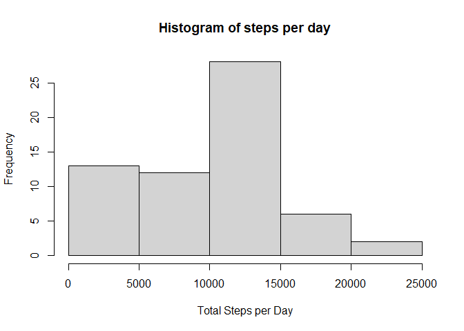

```r
sumStepsPerDay<-tapply(dt$steps, dt$date, sum,na.rm=TRUE)
meanStepsPerDay <- mean(sumStepsPerDay);
medianStepsPerDay <- median(sumStepsPerDay)
hist(sumStepsPerDay,main = 'Histogram of steps per day',xlab = 'Total Steps per Day')
```

```r
dev.copy(png,'figure/stepsPerDayHist.png')
dev.off();
```

The mean of total steps taken per day is 9354.2295082, the median is 10395.

## What is the average daily activity pattern?

We should average the number of steps by date. Some days have no value at all hence they should be excluded from the plot.

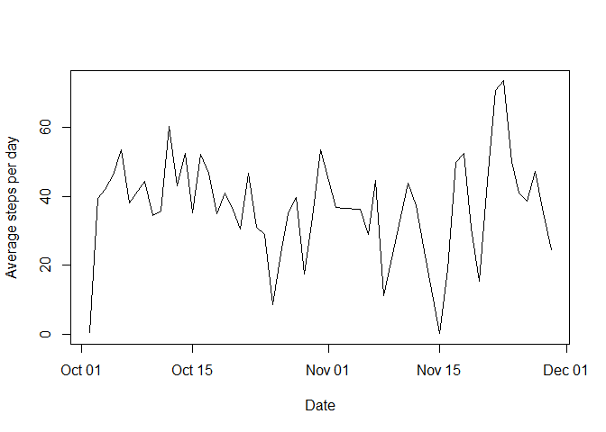

```r
averageStepsPerDay <-tapply(dt$steps, dt$date, mean,na.rm=TRUE)
availableDates <- !is.na(averageStepsPerDay)
plot(as.Date(names(averageStepsPerDay[availableDates])),
     averageStepsPerDay[availableDates],
     type='l',
     xlab = 'Date',
     ylab = 'Average steps per day')
```

```r
dev.copy(png,'figure/stepsPerDayTimeSeries.png')
dev.off()
```

## Imputing missing values

Data has 2304 `NA`s. We will impute the missing values by filling them with the mean of the 5-minute interval.

```r
meanStepsPerInterval <- tapply(dt$steps,dt$interval,mean,na.rm=TRUE)
newDt <- dt
intervals <- newDt[is.na(newDt$steps),'interval']

## Make sure to use `as.character()` with intervals

meanStepsPerInterval <- meanStepsPerInterval[as.character(intervals)]

newDt[is.na(newDt$steps),'steps'] <- meanStepsPerInterval
head(newDt)
```

```
##       steps       date interval            dateTime
## 1 1.7169811 2012-10-01        0 2012-10-01 00:00:00
## 2 0.3396226 2012-10-01        5 2012-10-01 00:05:00
## 3 0.1320755 2012-10-01       10 2012-10-01 00:10:00
## 4 0.1509434 2012-10-01       15 2012-10-01 00:15:00
## 5 0.0754717 2012-10-01       20 2012-10-01 00:20:00
## 6 2.0943396 2012-10-01       25 2012-10-01 00:25:00
```

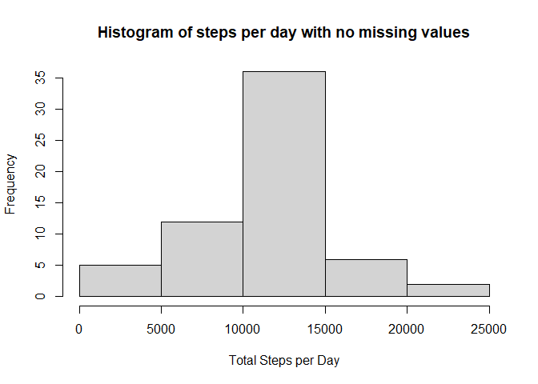

```r
sumStepsPerDayNoNAs<-tapply(newDt$steps, newDt$date, sum)
meanStepsPerDayNoNAs <- mean(sumStepsPerDayNoNAs)
medianStepsPerDayNoNAs <- median(sumStepsPerDayNoNAs)
hist(sumStepsPerDayNoNAs,
     main = 'Histogram of steps per day with no missing values',
     xlab = 'Total Steps per Day')
```

```r
dev.copy(png,'figure/stepsPerDayHistNoNas.png')
dev.off()
```

## Are there differences in activity patterns between weekdays and weekends?

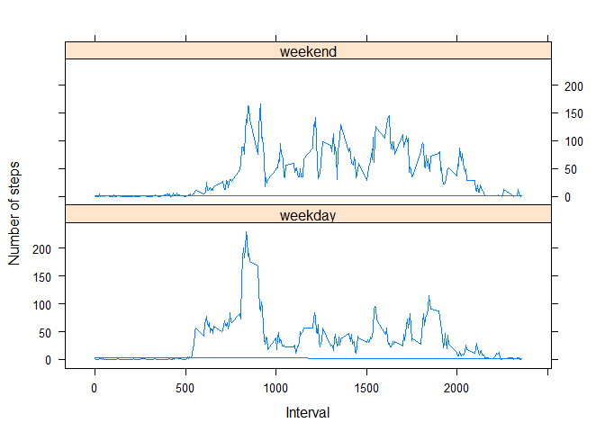

```r
library(lattice)

newDt$dayType <- ifelse(weekdays(newDt$date) %in% c('Saturday','Sunday'),'weekend','weekday')
newDt$dayType <- as.factor(newDt$dayType)

weekends <- subset(newDt,dayType=='weekend')
weekdays <- subset(newDt,dayType!='weekend')
averageStepsPerWeekend <- tapply(weekends$steps,weekends$interval,mean)

averageStepsPerWeekday <- tapply(weekdays$steps,weekdays$interval,mean)

finalDt <- data.frame(steps=c(averageStepsPerWeekend,averageStepsPerWeekday),
                      dayType = c(rep('weekend',length(averageStepsPerWeekend)),
                                  rep('weekday',length(averageStepsPerWeekday))) )

finalDt$invervals <- as.numeric(row.names(finalDt))

xyplot(steps~intervals|dayType ,
       data = finalDt,
       type='l',
       layout= c(1,2),
       ylab = 'Number of steps',
       xlab='Interval')
```

```r
dev.copy(png,'figure/stepsWeekdayWeekend.png')
dev.off()
```